# Chap7.3

Mijeong Kim

```r
library(tsibble)
library(tsibbledata)
library(tibble)
library(dplyr)
library(knitr)
library(ggplot2)
library(fpp3)
library(fpp2)
library(seasonal)
library(feasts)
library(GGally)
```

## 7.3 Evaluating the regression model

#### 잔차 정의

- 관측값$y_t$와 적합값$\hat{y}_t$의 차이를 **잔차(residual)** 라 하며, 다음과 같이 정의한다:

$$e_t = y_t - \hat{y}_t = y_t - \hat{\beta}_0 - \hat{\beta}_1 x_{1,t} -
\cdots - \hat{\beta}_k x_{k,t}$$

- 잔차는 각 관측값의 **예측 불가능한 요소**를 나타낸다.

#### 잔차의 주요 특성

- 잔차의 합은 0이다:$\sum_{t=1}^{T} e_t = 0$
- 각 설명 변수$x_k$와의 곱의 합도 0이다:$\sum_{t=1}^{T} x_{k,t} e_t = 0$
- 위 성질로 인해 **잔차의 평균은 0**이며, **설명 변수와의 상관관계도 0**이 된다 (단, 절편이 포함된 경우에 한함).

#### 잔차 분석의 중요성

- 회귀 모델 적합 후에는 **잔차 플롯을 통해 가정이 충족되었는지 확인**해야 한다.
- 잔차 분석은 모델의 타당성을 점검하고, 예측력을 개선하는 데 도움이 된다.

### ACF(자기상관 함수) 플롯

- 시계열 데이터에서는 잔차에 **자기상관(autocorrelation)** 이 존재할 수 있다.
- 잔차에 자기상관이 있으면 예측에 필요한 정보가 모델에 반영되지 않았다는 뜻이며, **예측 구간이 비효율적으로 넓어질 수 있다**.
- 따라서 항상 **잔차의 ACF 플롯을 확인**해 자기상관 여부를 검토해야 한다.

#### 잔차의 히스토그램

- 잔차가 **정규분포를 따르는지 확인**하는 것이 좋다.
- 정규성은 예측 자체에는 필수가 아니지만, **예측 구간 계산을 단순화**시킨다.

#### 예시: 유용한 잔차 진단 방법

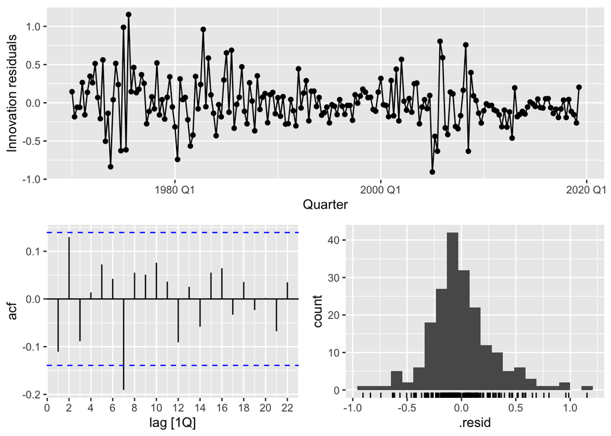

```r
fit_consMR <- us_change |>
  model(tslm = TSLM(Consumption ~ Income + Production +
                                    Unemployment + Savings))

fit_consMR |> gg_tsresiduals()
```

Figure 7.8: Analysing the residuals from a regression model for US quarterly consumption.

```r
augment(fit_consMR) |>
  features(.innov, ljung_box, lag = 10)
```

```
## # A tibble: 1 × 3
##   .model lb_stat lb_pvalue
##   <chr>    <dbl>     <dbl>
## 1 tslm      18.9    0.0420
```

#### 시계열 플롯 (Time Plot)

- 잔차의 시계열 플롯은 **시간에 따라 분산이 변화하는 이분산성(heteroscedasticity)** 을 보인다.
- 이로 인해 **예측 구간의 신뢰도(coverage probability)** 가 부정확해질 수 있다.

#### 히스토그램 (Histogram)

- 잔차의 히스토그램은 **약간의 왜도(skewness)** 를 보인다.
- 이 역시 예측 구간의 신뢰도에 영향을 줄 수 있다.

#### 자기상관 플롯 (ACF Plot)

- 지연 7(lag 7)에서 **유의한 스파이크**가 나타난다.
- 하지만 자기상관의 크기가 크지 않아 예측이나 예측 구간에 큰 영향은 없을 것으로 본다.
- **잔차에 남은 정보를 반영하는 동적 회귀 모델**은 10장에서 설명한다.

### 예측 변수와의 잔차 산점도

- **잔차는 예측 변수들과 무작위로 흩어진 형태**를 보여야 하며, 규칙적인 패턴이 없어야 한다.
- 패턴이 있다면 비선형 관계일 가능성이 있으므로, 모델 수정을 고려해야 한다.
- **모델에 포함되지 않은 예측 변수**와의 잔차도 확인해야 하며, 패턴이 보인다면 해당 변수를 (비선형 형태로) 모델에 포함할 수 있다.

## 예시: 미국 소비 지출 예측 모델

- 그림 7.9의 잔차 산점도에서, 모든 예측 변수와의 잔차는 **무작위로 흩어져 있어** 모델에 문제가 없는 것으로 판단한다.

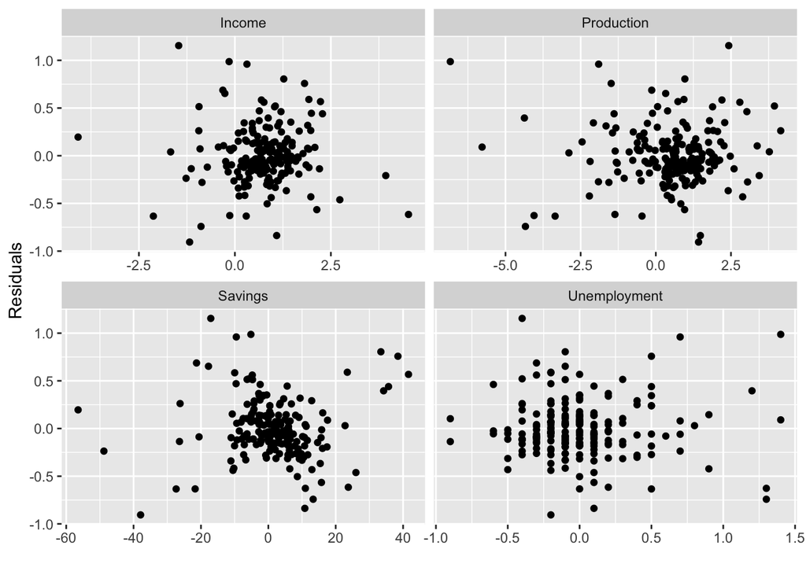

```r
us_change |>
  left_join(residuals(fit_consMR), by = "Quarter") |>
  pivot_longer(Income:Unemployment,
               names_to = "regressor", values_to = "x") |>
  ggplot(aes(x = x, y = .resid)) +
  geom_point() +
  facet_wrap(. ~ regressor, scales = "free_x") +
  labs(y = "Residuals", x = "")
```

Figure 7.9: Scatterplots of residuals versus each predictor.

### 잔차 vs 적합값 플롯 (Residuals vs Fitted Values)

- 잔차를 적합값에 대해 플로팅하면, **아무런 패턴이 없는 무작위 산점도**여야 한다.
- 만약 **특정한 패턴**이 보인다면, 이는 오차의 분산이 일정하지 않은 **이분산성(heteroscedasticity)** 문제일 수 있다.
- 이 경우, 예측 변수에 **로그(log)나 제곱근(sqrt)** 등의 **변환(transformation)** 을 적용하는 것이 도움이 될 수 있다 (3.1절 참고).

### 예시: 미국 소비 지출 예측

- 이전 예제를 계속해서, 그림 7.10에서는 잔차가 적합값에 대해 **무작위로 흩어져 있는 모습**을 보인다.
- 이는 **오차가 등분산(homoscedastic)** 이라는 점을 시사한다.

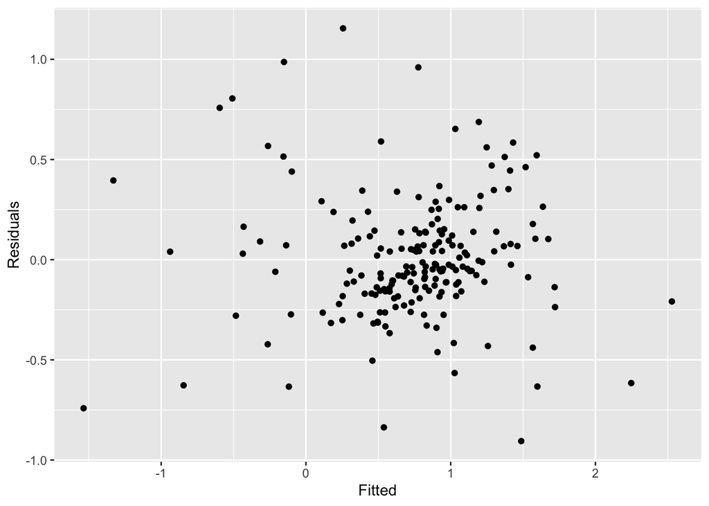

```r
augment(fit_consMR) |>
  ggplot(aes(x = .fitted, y = .resid)) +
  geom_point() + labs(x = "Fitted", y = "Residuals")
```

Figure 7.10: Scatterplots of residuals versus fitted values.

### 이상치(Outliers)와 영향력 있는 관측값(Influential Observations)

- **이상치**란 대부분의 데이터와 비교해 **극단적인 값을 가지는 관측값**을 말한다.
- **영향력 있는 관측값**은 회귀 모델의 계수 추정에 **큰 영향을 미치는 관측값**이며, 보통 x 방향으로 극단적인 경우가 많다.

#### 이상치 탐지 및 처리

- 이상치와 영향력 있는 값은 공식적인 통계 기법으로 탐지할 수 있으나, 해당 교재의 범위를 벗어난다.
- 분석 전 **데이터를 충분히 탐색**하는 것이 중요하다 (2장 참조).
- \( y \)와 각 \( x \) 간의 **산점도**는 이상치를 식별하는 데 유용한 도구다.
- **입력 오류**로 인해 발생한 이상치는 최소/최대값 등을 통해 쉽게 탐지할 수 있으며, 확인되면 즉시 **수정하거나 제거**해야 한다.

#### 해석과 판단

- 어떤 이상치는 단순히 **정상적인 데이터와 다른 특이값**일 수 있으며, 반드시 제거해야 하는 것은 아니다.
- 이상치가 확인되었을 때는 그 **원인을 분석**하고, **제거 여부를 신중하게 결정**해야 한다.
- 가능하다면, **이상치를 포함한 결과와 제외한 결과를 함께 보고**하는 것이 바람직하다.

### 허위 회귀 (Spurious Regression)

- 시계열 데이터는 대부분 **비정상(non-stationary)** 특성을 가진다.
  - 즉, 일정한 평균이나 분산을 중심으로 변동하지 않는다.
- 비정상 시계열 데이터를 회귀 분석에 사용하면, **실제로 관련이 없는 변수들 사이에도 통계적으로 유의한 관계가 나타날 수 있다**.
- 이러한 현상을 **허위 회귀(spurious regression)** 라고 한다.

#### 예시

> 시계열의 정상성(stationarity)에 대한 자세한 내용은 **9장에서** 다룬다.

#### 비정상 시계열 회귀의 문제점

- **비정상(non-stationary)** 시계열끼리 회귀를 수행하면 **허위 회귀(spurious regression)** 가 발생할 수 있다.
- 예시로, **호주의 항공 여객 수**를 **기니의 쌀 생산량**에 회귀한 결과는 **높은 \( R^2 \)** 와 **잔차의 자기상관**을 보인다 (그림 7.13 참고).
- 이러한 특성은 **허위 회귀의 전형적인 신호**이다.

#### 허위 회귀의 예측 문제

- 허위 회귀는 **단기적으로는 그럴듯한 예측 결과를 낼 수 있지만**, 시간이 지남에 따라 예측력이 크게 떨어진다.
- 따라서 장기적 예측이나 해석에는 적합하지 않다.

> 비정상 시계열과 허위 회귀에 대한 보다 자세한 내용은 **10장에서** 다룬다.

```r
fit <- aus_airpassengers |>
  filter(Year <= 2011) |>
  left_join(guinea_rice, by = "Year") |>
  model(TSLM(Passengers ~ Production))
report(fit)
```

```
## Series: Passengers
## Model: TSLM
##
## Residuals:
##     Min      1Q  Median      3Q     Max
## -5.9448 -1.8917 -0.3272  1.8620 10.4210
##
## Coefficients:
##             Estimate Std. Error t value Pr(>|t|)
## (Intercept)   -7.493      1.203  -6.229 2.25e-07 ***
## Production    40.288      1.337  30.135  < 2e-16 ***
## ---
## Signif. codes:  0 '***' 0.001 '**' 0.01 '*' 0.05 '.' 0.1 ' ' 1
##
## Residual standard error: 3.239 on 40 degrees of freedom
## Multiple R-squared: 0.9578,  Adjusted R-squared: 0.9568
## F-statistic: 908.1 on 1 and 40 DF, p-value: < 2.22e-16
```

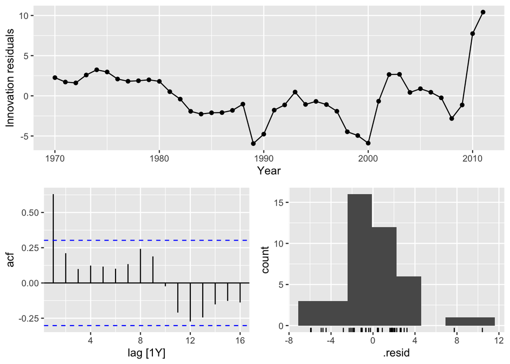

```r
fit |> gg_tsresiduals()
```

Figure 7.13: Residuals from a spurious regression.